# Calculating capacitances

# Example of solving the Poisson problem with different boundary conditions and manipulation of the solution for the capacitance calculation problem

The problem to be solved is:

\[ \begin{align} -\Delta u &= f \;\;\;\;\; \text{in } \Omega \\ u &= g \;\;\;\;\; \text{in } \partial \Omega_{int} \\ \hat{n} \cdot \nabla u &= h \;\;\;\;\; \text{in } \partial \Omega_{ext} \\ \end{align} \]

To do this, we will impose its weak form:

Find $u \in H^1(\Omega)$ with $u = g$ on $\partial \Omega_{int}$ such that,

\[ \int_{\Omega} \nabla v \cdot \nabla u \; d\Omega - \int_{\Omega} v \; f \; d\Omega - \oint_{\partial \Omega_{ext}} v \; h \; d\Gamma = 0 \;\;\;\;\; \forall v \;\; \in H^1_0(\Omega, \partial \Omega_{int}) \]

If we obtain a $u$ satisfying this equation, and it is sufficiently smooth, then we can integrate the first term by parts and obtain:

\[ \int_{\Omega} v \; (-\Delta u - f) \; d\Omega + \oint_{\partial \Omega_{ext}} v \; (\hat{n} \cdot \nabla u - h) \; d\Gamma = 0 \;\;\;\;\; \forall v \;\; \in H^1_0(\Omega, \partial \Omega_{int}) \]

Taking $v$ arbitrary but with compact support, we see that $u$ must satisfy:

\[ -\Delta u = f \;\;\;\;\; \text{in } \Omega, \]

and taking now $v$ arbitrary on $\partial \Omega_{ext}$ we also see that the Neumann condition must be satisfied,

\[ \hat{n} \cdot \nabla u = h \;\;\;\;\; \text{in } \partial \Omega_{ext}. \]

The Dirichlet condition is imposed directly on the space where we look for $u$.

We will then use the solution found for a capacitance problem.

To solve the problem, we will use the infrastructure of the Julia package `Gridap.jl`. This example is a compilation of several examples from the package's tutorial.

```julia
using Gridap
using FileIO #Gráficos y salidas
using GridapGmsh
#using gmsh #]add https://github.com/koehlerson/gmsh.jl.git
#NEVER USE using Gmsh!!!
#import Gmsh: gmsh
mkpath("images") # output folder for the .vtu files
```

```
"images"
```

```julia
#plot_s = false #true
plot_s = true
if plot_s
    #using Pkg; Pkg.activate("./gridap_makie")
    #Pkg.add(Pkg.PackageSpec(;name="Makie", version="0.12"))
    using GridapMakie
    if get(ENV, "CI", "false") == "true"
        using CairoMakie # the web page is built on a server without a display
    else
        using GLMakie
        GLMakie.activate!(inline=true) # For windows on the notebook itself. Comment out if you want the as pop-out plots.
    end
end
```

We will use meshes built with the `gmsh` library, through the script `mesh_generator.jl`. Note that in the script, the three boundaries are named: the external (rectangular) one as `"ext"` and the internal ones as `"inner_circle"` and `"inner_square"`. Based on the script and following the `gmsh` tutorial, you can build other meshes as well. Other libraries can also be used to build meshes. These are imported into the **Gridap** infrastructure, and with them the triangulation to be used is constructed.

```julia
create_grid = false

#Grid resolution:
res = 1 # 1, 2 or 3
```

```
1
```

```julia
if create_grid

using GridapGmsh: gmsh
include("mesh_generator.jl") # from the Lab 7 folder
grid_type = "rectangle_hole_square"

#Resoluciones:
res = 1

if res == 1
    lc = 1e-1
    lc_f = 0.25e-1
    name = grid_type * "_coarse"
elseif res == 2
    lc = 5e-2
    lc_f = 2.5e-2
    name = grid_type * "_intermediate"
elseif res == 3
    lc = 1e-2
    lc_f = 0.25e-2
    name = grid_type * "_finner"
end

#Lados exteriores de la grilla rectangular
side_x = 2
side_y = 1

#Rectangulo interior
rec_base = 0.25  #Coordenada y de la base
rec_top = 0.75   #Coordenada y del lado superior
rec_left = 1.25  #Coordenada x del lado izquierdo
rec_right = 1.75 #Coordenada x del lado derecho

#Circulo interior
circ_center_x = 0.5  #Coordenada x del centro
circ_center_y = 0.5  #Coordenada y del centro
circ_radius = 0.25   #Radio



p = (name, side_x, side_y, circ_center_x, circ_center_y, circ_radius, rec_base, rec_top, rec_left, rec_right, lc, lc_f)

model = make_model(grid_type, p)

end
```

You can also upload the grid once is created and stored in the directory: models

```julia
if create_grid == false
    model = GmshDiscreteModel("models/rectangle_hole_square_coarse.msh")
end
```

```
Info    : Reading 'models/rectangle_hole_square_coarse.msh'...
Info    : 26 entities
Info    : 966 nodes
Info    : 1934 elements
Info    : Done reading 'models/rectangle_hole_square_coarse.msh'
UnstructuredDiscreteModel()
```

```julia
Ω = Triangulation(model)
```

```
BodyFittedTriangulation()
```

```julia
degree = 3
dΩ = Measure(Ω,degree)
```

```
GenericMeasure()
```

```
CairoMakie.Screen{IMAGE}
```

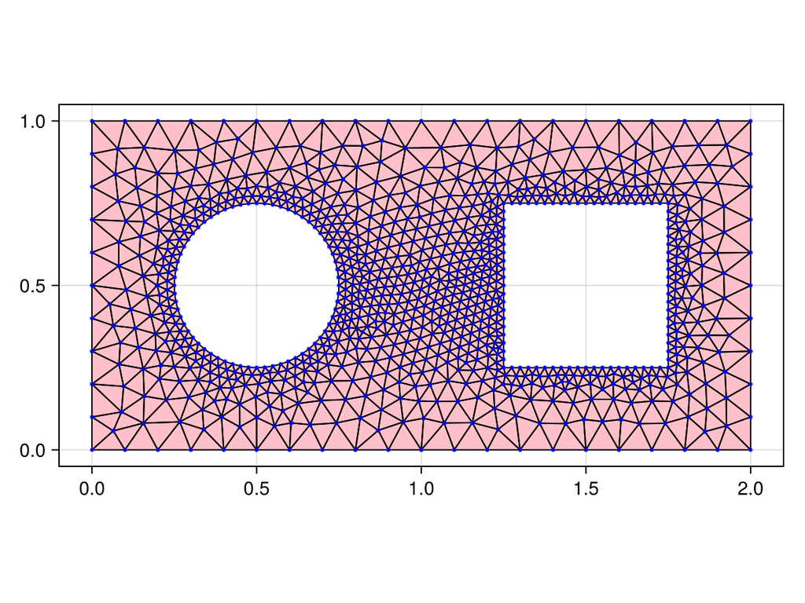

```julia
if plot_s
    fig, ax = plot(Ω)
    ax.aspect = AxisAspect(2)
    wireframe!(Ω, color=:black, linewidth=1)
    scatter!(Ω, marker=:star8, markersize=4, color=:blue)
    fig
end
display(fig)
```

We can also plot the different boundaries:

```
CairoMakie.Screen{IMAGE}
```

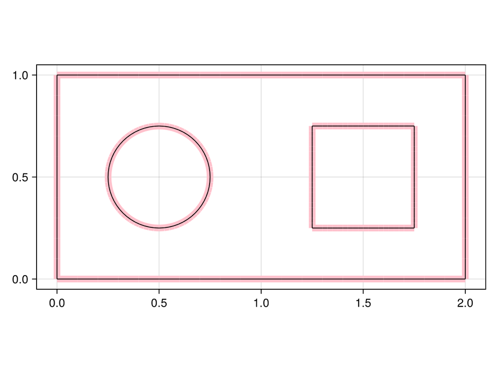

```julia
boundary_tags = ["inner_circle", "inner_square", "ext"]

Γ = BoundaryTriangulation(model,tags=boundary_tags)
dΓ = Measure(Γ,degree)

if plot_s
    fig, ax = plot(Γ, linewidth=8)
    ax.aspect = AxisAspect(2)
    wireframe!(Γ, color=:black, linewidth=1)
    fig
end
display(fig)
```

We are going to choose two simple problems to calculate the capacitance matrix of a set of conductors. We will take the conductors as the two bodies: the circle and the square, and we will set constant potential conditions. The external boundary will be considered as *infinity* and we will always set the potential to zero there.

```julia
capacity_cs = false # potencial 1 en el círculo y potencial 0 en el cuadrado.
capacity_sc = false # potencial 0 en el círculo y potencial 1 en el cuadrado.
capacity_cs = true
#capacity_sc = true
```

```
true
```

```julia
order = 1
reffe = ReferenceFE(lagrangian,Float64,order)

dirichlet_tags= ["inner_circle", "inner_square","ext"]

V = TestFESpace(model,reffe;conformity=:H1,dirichlet_tags = dirichlet_tags)
#V = TestFESpace(model,reffe;conformity=:L2,dirichlet_tags = dirichlet_tags) #no funciona la inversión.
```

```
UnconstrainedFESpace()
```

We now assign the boundary values:

```julia
# internal Dirichlet boundary condition
g(x) = 1.0 # esta puede ser una función de x (vector posición)
if capacity_cs
    U = TrialFESpace(V,[g 0.0 0.0])
elseif capacity_sc
    U = TrialFESpace(V,[0.0 g 0.0])
end
```

```
TrialFESpace()
```

Next we define the weak problem in abstract form:

```julia
f(x) = 0 # in this case we are taking the source to vanish, but in principle we could put a charge distribution inside.

a(u,v) = ∫( ∇(v)⋅∇(u) )*dΩ  # in a(u,v) goes all the terms linear in the unknown, u.

b(v) = ∫(v*f )*dΩ # here everything else.
```

```
b (generic function with 1 method)
```

From this point on the package **Gridap.jl** generates a system of the form: $Ax=b$ and solves it for $u$ in the finite element version given. It first computes the matrices:

```julia
op = AffineFEOperator(a,b,U,V)
```

```
AffineFEOperator()
```

```julia
ls = LUSolver()
lb = BackslashSolver() # x = A \ b
solver = LinearFESolver(lb)
```

```
LinearFESolver()
```

And we solve it. We call the solution $u_h$.

```julia
uh = solve(solver,op)
#uh = solve(op)
```

```
SingleFieldFEFunction():
 num_cells: 1730
 DomainStyle: Gridap.CellData.ReferenceDomain()
 Triangulation: BodyFittedTriangulation()
 Triangulation id: 11465775172895354621
```

Now we can plot the found approximation and also save it in a format that can be given to Paraview or VisIt for ploting and processing.

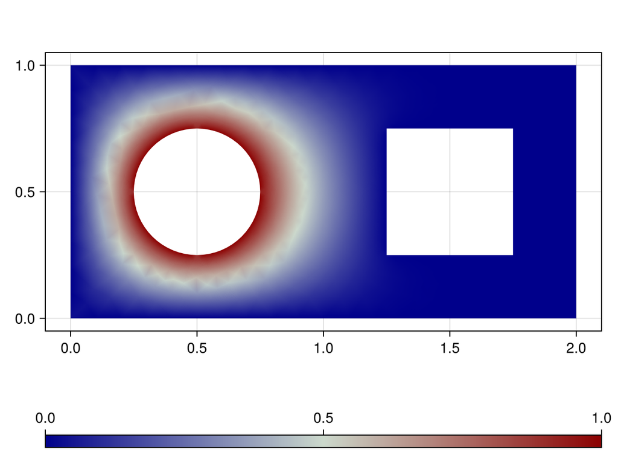

```julia
if plot_s
    fig, ax, plt = plot(Ω, uh)
    ax.aspect = AxisAspect(2)
    Colorbar(fig[2,1], plt, vertical=false)
    fig
end
```

```julia
if capacity_cs
    writevtk(Ω,"images/solucion_cs_$res",cellfields=["uh_cs_$res" => uh])
    writevtk(Ω,"images/grad_cs_$res",cellfields=["grad_uh_cs_$res" => ∇(uh)])
elseif capacity_sc
    writevtk(Ω,"images/solucion_sc_$res",cellfields=["uh_sc_$res" => uh])
    writevtk(Ω,"images/grad_sc_$res",cellfields=["grad_uh_sc_$res" => ∇(uh)])
end
```

```
(["images/grad_cs_1.vtu"],)
```

```julia
Γ_ext = BoundaryTriangulation(model,tags="ext")
dΓ_ext = Measure(Γ_ext,degree)
nb_ext = get_normal_vector(Γ_ext) # this is the normal to the boundary.
Q_ext = -sum(∫((nb_ext ⋅ ∇(uh)))*dΓ_ext)/4/π
```

```
0.5543997966789106
```

```julia
Γ_square = BoundaryTriangulation(model,tags="inner_square")
dΓ_square = Measure(Γ_square,degree)
nb_square = get_normal_vector(Γ_square)
Q_square = sum(∫((nb_square ⋅ ∇(uh)))*dΓ_square)/4/π
```

```
-0.05449751663262792
```

```julia
Γ_circle = BoundaryTriangulation(model,tags="inner_circle")
dΓ_circle = Measure(Γ_circle,degree)
nb_circle = get_normal_vector(Γ_circle)
Q_circle = sum(∫((nb_circle ⋅ ∇(uh)))*dΓ_circle)/4/π
```

```
0.5699519546685845
```

```julia
Q_ext - Q_circle - Q_square # this number should vanish if there are no sources (charges) present.
```

```
0.03894535864295401
```

We show an image with the program VisIt:

[figure not shown]